# 电子/半导体/集成电路工程师招聘和薪酬水平

## 总述

本次采集有效数据18976条(城市发布量>=100)，主要分析电子、半导体、集成电路工程师招聘和薪酬水平，我们将从如下方面分析：

## 01.城市分布

[figure not shown]

roadmap

## 02.行业分布

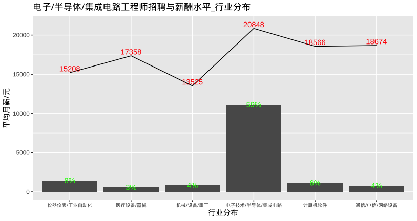

industries

## 03.公司规模

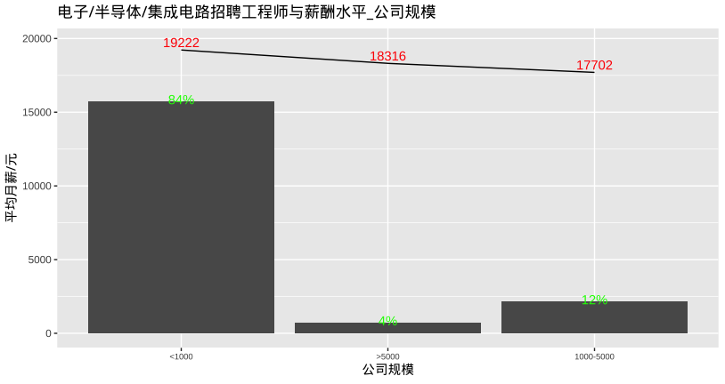

com_size

## 04.公司类型

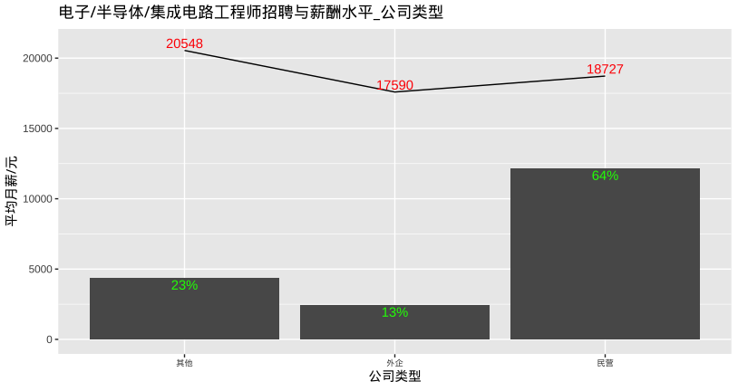

com_type

## 05.工作经验

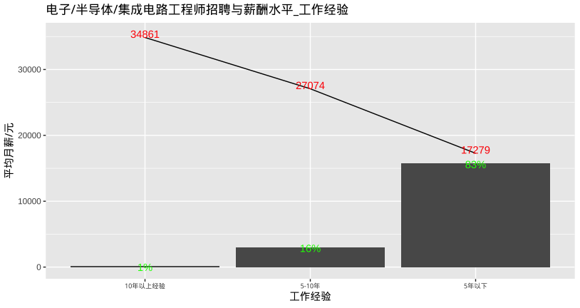

experience

## 06.学历要求

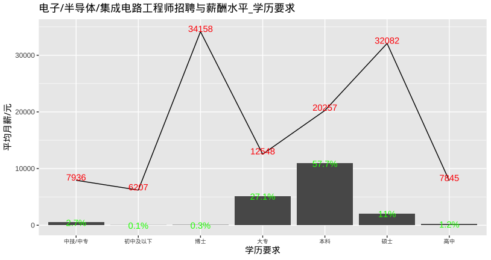

education

## 07.细分岗位

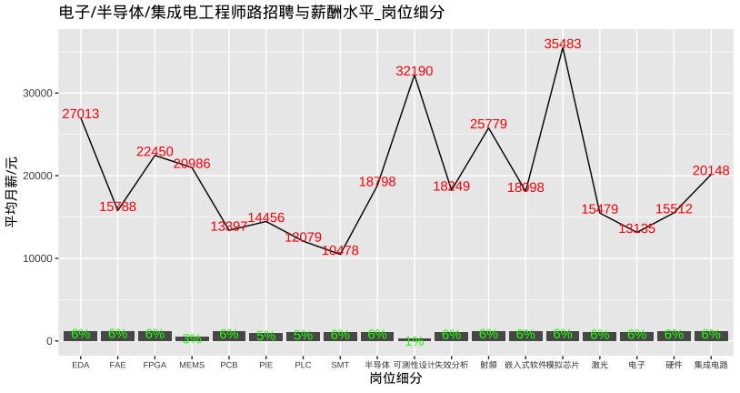

subclass